# GIS Code

Rebecca Irons (IRNREB001)

2022-04-19

## GIS Assignment

#### Section 1: Install and Load Packages

#### Section 2: Tidy SAFRING Data

#### Section 3: Tidy Geographic Pentad Data

#### Section 4: Creating the Map

This document provides step-by-step instructions to create a map of the localities of where malachite sunbirds have been ringed across South Africa, from east by KwaZulu-Natal to west. The data for this species is accessed from SAFRING using an API. For more details on the SAFRING database, see https://safring.birdmap.africa/.

### Section 1

##### In this section, we will install and load the necessary packages to read in the data from the SAFRING database, tidy the data and use GIS tools to create a map.

First, the work space must be clean.

```r
rm(list = ls())
```

Install the necessary packages:

- ‘Tidyverse’ is required to manipulate the data:

```r
install.packages("tidyverse", repos = "http://cran.us.r-project.org")
```

- ‘RCurl’ and ‘rjson’ is required to access the data from SABAP2 using as API.

```r
install.packages("RCurl", repos = "http://cran.us.r-project.org")

install.packages("rjson", repos = "http://cran.us.r-project.org")
```

- ‘sf’ is required to work with vector data to create a map

```r
install.packages("sf", repos = "http://cran.us.r-project.org")
```

- to create the basemap for the map of longitudes and latitudes of localities of the malachite sunbird, we need to install two packages:

```r
install.packages("rosm", repos = "http://cran.us.r-project.org")

install.packages("ggspatial", repos = "http://cran.us.r-project.org")
```

The next step after installation is to load all the necessary packages.

The packages from the tidyverse have to be loaded. These packages are:

```r
library(dplyr)

library(ggplot2)

library(broom)
```

The packages required for loading in the data from the SAFRING website are:

```r
library(RCurl)

library(rjson)
```

The packages required for working with the vector data are:

```r
library(sf)
```

The packages required for creating a basemap are:

```r
library(rosm)
library(ggspatial)
```

Using an API, access the SAFRING database and load the data for your focal species. The species codes can be changed here (the ‘SPP’ object) to change the species of focus.

```r
SPP = 751
ringing_data <- read.csv(paste('https://api.birdmap.africa/safring/species/records_list/',SPP,'?format=csv',sep=""))
```

### Section 2

##### The species data accessed from the SAFRING database need to be tidied first before we look at the spatial data. This is so that the dataset from which we are drawing the pentad data contains only observations that are sensical. These same steps have been followed in the data management assignment for tidying the SAFRING data.

The ages that are recorded for the birds in the database must be numeric and the juveniles must be filtered out from the adults. We will only be working with adults.

```r
ringing_data$Age <- as.numeric(ringing_data$Age)

ringing_data <- filter(ringing_data, Age>3)
```

The metric data (tarsus length, mass etc) needs to be tidied. These data must be numeric.

```r
ringing_data$Mass <- as.numeric(as.character(ringing_data$Mass))

ringing_data$Wing <- as.numeric(as.character(ringing_data$Wing))

ringing_data$Culmen <- as.numeric(as.character(ringing_data$Culmen))

ringing_data$Head <- as.numeric(as.character(ringing_data$Head))

ringing_data$Tarsus <- as.numeric(as.character(ringing_data$Tarsus))
```

A common issue in the SAFRING database is that volunteers fill in some metric data in with a zero as opposed to leaving it blank. Therefore, these zeros need to be removed as a zero length - for example - does not make sense.

```r
ringing_data$Mass[ringing_data$Mass==0] <- NA

ringing_data$Wing[ringing_data$Wing==0] <- NA

ringing_data$Head[ringing_data$Head==0] <- NA

ringing_data$Culmen[ringing_data$Culmen==0] <- NA

ringing_data$Tarsus[ringing_data$Tarsus==0] <- NA

ringing_data$Tail[ringing_data$Tail==0] <- NA
```

```r
checkmass <- ringing_data%>%filter(!is.na(Mass))%>%do(data.frame(lc=quantile(.$Mass, c(.05)), uq=quantile(.$Mass, c(.995)), n=length(.$Mass) ))

checkWing <- ringing_data%>%filter(!is.na(Wing))%>%do(data.frame(lcwing=quantile(.$Wing, c(.005)), uqwing=quantile(.$Wing, c(.995)), n=length(.$Wing)))

checkTarsus <- ringing_data%>%filter(!is.na(Tarsus))%>%do(data.frame(lctarsus=quantile(.$Tarsus, c(.005)), uqtarsus=quantile(.$Tarsus, c(.995)), n=length(.$Tarsus)))

checkHead <- ringing_data%>%filter(!is.na(Head))%>%do(data.frame(lcHead=quantile(.$Head, c(.005)), uqHead=quantile(.$Head, c(.995)), n=length(.$Head)))

checkCulmen <- ringing_data%>%filter(!is.na(Culmen))%>%do(data.frame(lcCulmen=quantile(.$Culmen, c(.005)), uqCulmen=quantile(.$Culmen, c(.995)), n=length(.$Culmen)))

checkTail <- ringing_data%>%filter(!is.na(Tail))%>%do(data.frame(lcTail=quantile(.$Tail, c(.005)), uqTail=quantile(.$Tail, c(.995)), n=length(.$Tail)))


ringing_data$masscheck <- NA

ringing_data$wingcheck <- NA

ringing_data$headcheck <- NA

ringing_data$culmencheck <- NA

ringing_data$tailcheck <- NA
```

We then need to validate each measurement (inside the 99 quantile) by starting a loop through the data of the focal species.

```r
for(k in 1:nrow(ringing_data)){

  ringing_data$masscheck[k] <- ifelse(ringing_data$Mass[k]<checkmass$uq & ringing_data$Mass[k]>checkmass$lc , "OK", "error")

  ringing_data$wingcheck[k] <- ifelse(ringing_data$Wing[k]<checkWing$uq & ringing_data$Wing[k]>checkWing$lc , "OK", "error")

  ringing_data$tarsuscheck[k] <- ifelse(ringing_data$Tarsus[k]<checkTarsus$uq & ringing_data$Tarsus[k]>checkTarsus$lc , "OK", "error")

  ringing_data$headcheck[k] <- ifelse(ringing_data$Head[k]<checkHead$uq & ringing_data$Head[k]>checkHead$lc , "OK", "error")

  ringing_data$culmencheck[k] <- ifelse(ringing_data$Culmen[k]<checkCulmen$uq & ringing_data$Culmen[k]>checkCulmen$lc , "OK", "error")

  ringing_data$tailcheck[k] <- ifelse(ringing_data$Tail[k]<checkTail$uq & ringing_data$Tail[k]>checkTail$lc , "OK", "error")
}
```

The ‘NAs’ then need to be replaced with ‘OK’ to soften the next filter step.

```r
ringing_data$masscheck[is.na(ringing_data$masscheck)] <- "OK"

ringing_data$tarsuscheck[is.na(ringing_data$tarsuscheck)] <- "OK"

ringing_data$headcheck[is.na(ringing_data$headcheck)] <- "OK"

ringing_data$culmencheck[is.na(ringing_data$culmencheck)] <- "OK"

ringing_data$tailcheck[is.na(ringing_data$tailcheck)] <- "OK"
```

The object containing the data for the focal species then needs to be redefined with the error filtered out.

```r
ringing_data <- filter(ringing_data, masscheck!='error', tarsuscheck!='error',headcheck!='error',culmencheck!='error',tailcheck!='error')
```

We need to range check against SABAP2 data, if there are SABAP2 records for the SAFRING ringing locations of the chosen species.This step will remove ringing locations that are completely wrong, such as those that are in the middle of the ocean. This step also makes it easy to then remove ‘NA’ values, which compromise one’s ability to produce the basemap as errors tend to pop up with missing values.

```r
sabap2url <- paste('https://api.birdmap.africa/sabap2/v2/cards/species/info/',SPP,'?format=csv',sep="")
sabap2data <- read.csv(sabap2url)

Spp_pentads <- unique(sabap2data$Pentad)
temp <- filter(ringing_data, pentad%in%Spp_pentads)
```

```r
temp$BP <-  as.numeric(temp$Brood_patch)

temp$BP <-  ifelse(temp$BP >0 , 1, temp$BP)

temp$BP <-  ifelse(temp$BP <0 , 0, temp$BP)

temp$BP <-  ifelse(temp$Brood_patch %in% c("1.0", "2.0", "y", "BP", "Brood Patch") , 1, temp$BP)

temp$BP <-  ifelse(temp$Brood_patch %in% c("-1.0", "n", "N", "no") , 0, temp$BP)
```

The date information that is recorded in the SABAP2 database has to be cleaned and organized as well.

```r
temp$Startdate1 <- as.Date(temp$Startdate, "%Y-%m-%d")

temp$Month <- format(temp$Startdate1, "%m")

temp$Month <- as.numeric(temp$Month)

temp$Year <- format(temp$Startdate1, "%Y")
```

Next, the moult data must be numeric and filtered to remove NA values, which imply that active moult is not occurring.

```r
temp$Moult <- as.numeric(temp$Moult)

temp <- filter(temp, !is.na(Moult))

temp$gender <- ifelse(temp$Sex==1, "Male", ifelse(temp$Sex==2, "Female", NA))

temp$active_moult <- ifelse(temp$Moult>0&temp$Moult<5555555555, 1, 0)
```

### Section 3

##### The geographic pentads in the SAFRING database contain spatial information (latitude and longitude). However, to work with this spatial information, latitude and longitude values contained within the pentad object need to be separated to tidy the data and work with the “sf” package.

There are two functions that we need to get sections of the pentads for mapping.

```r
left = function(text, num_char) {substr(text, 1, num_char)}
mid = function(text, start_num, num_char) {  substr(text, start_num, start_num + num_char - 1)}
```

We then have to tidy the pentad data to pull out rough latitude and longitude values.

```r
temp$Lat <- as.numeric(left(temp$pentad, 2)) +  as.numeric(mid(temp$pentad, 3, 2))/60
temp$Latitude <- ifelse(mid(temp$pentad,5,1)=="_", temp$Lat*-1, temp$Lat)
temp$Longitude <- as.numeric(mid(temp$pentad, 6,2)) +  as.numeric(mid(temp$pentad, 8, 2))/60
```

We now have two objects called Latitude and Longitude in the ringing data for the malachite sunbird so that we can map the localities of this species across South Africa.

We need to then coarsely split the spatial data by longitude, creating an additional column with the locations split into east and west for the malachite sunbird.

```r
temp$West_East <- ifelse(temp$Longitude<27, "West", "East")
```

Let’s check the class of the ringing data. We need this data set to be a data frame so that we can convert these data into spatial data.

```r
class(temp)
```

```
## [1] "data.frame"
```

Now, this data frame has to be converted to a spatial object. We have to convert this object ‘Locations’ of class = sf. The coordinate reference system (CRS) also have to be defined. The CRS should be defined to be Geographic WGS84 using the EPSG code (4326).

```r
Locations <- st_as_sf(temp, coords = c("Longitude", "Latitude"), crs = 4326)
```

To check if this data frame has been correctly converted, we need to use the class() function.

```r
class(Locations)
```

```
## [1] "sf"         "data.frame"
```

We also need to see the variable ‘geometry’ is contained within the variable Locations when we use the function names().

```r
names(Locations)
```

```
##  [1] "ID"             "Scheme"         "Ring_number"    "Code"
##  [5] "Startdate"      "Spp"            "Primary_Ringer" "Age"
##  [9] "Sex"            "Location_code"  "Mass"           "Wing"
## [13] "Head"           "Culmen"         "Tail"           "Tarsus"
## [17] "Brood_patch"    "Moult"          "Country"        "pentad"
## [21] "masscheck"      "wingcheck"      "headcheck"      "culmencheck"
## [25] "tailcheck"      "tarsuscheck"    "BP"             "Startdate1"
## [29] "Month"          "Year"           "gender"         "active_moult"
## [33] "Lat"            "West_East"      "geometry"
```

### Section 4

##### The purpose of this section is to create a map of southern Africa as a basemap to the localities of malachite sunbirds ringed across South Africa. We want to split these localities according to whether they are considered ‘east’ or ‘west’. This is important because we want to be able to link different moult and breeding patterns in nectarivores across South Africa to geospatial variability in resources. Therefore, we need to visually differentiate between east and west so that we can draw conclusions about resource availability and these different patterns.

First, lets create a map of the locations in space separated according to their west/east positions.

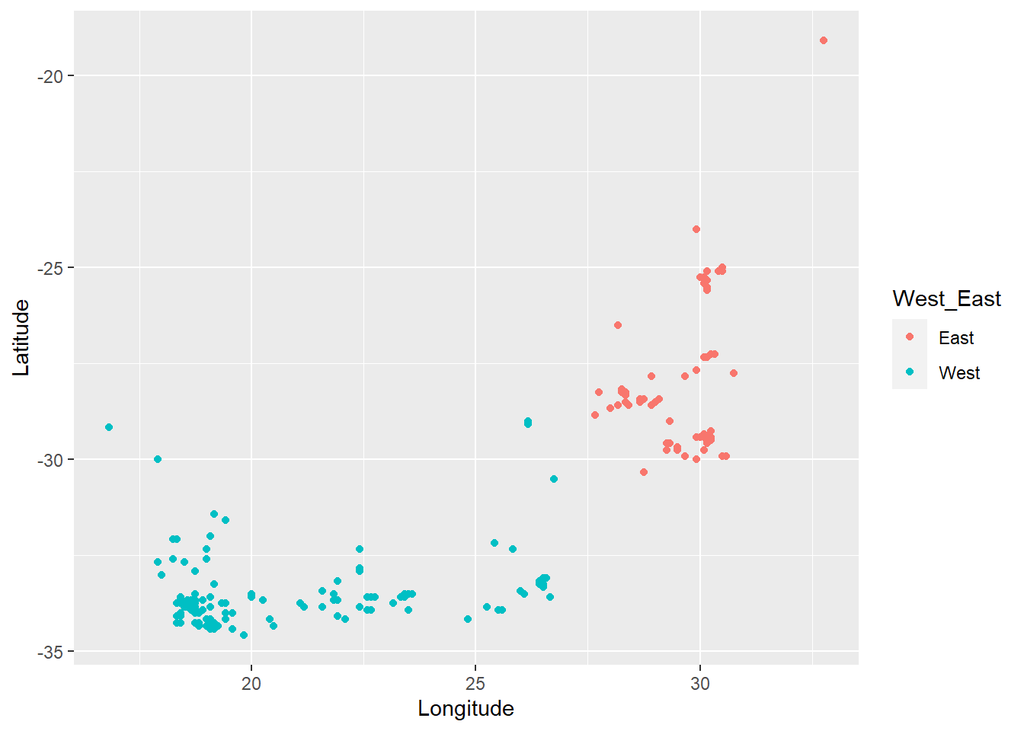

```r
ggplot(temp, aes(Longitude, Latitude, colour = West_East))+geom_point()
```

We could make this map look even better by creating a basemap to these latitude and longitude values. We can then have a clearer picture of how the ringing localities of Malachite Sunbirds are spread across South Africa.

The’zoomin = ’can be removed or changed to 0 to edit the resolution of the map.

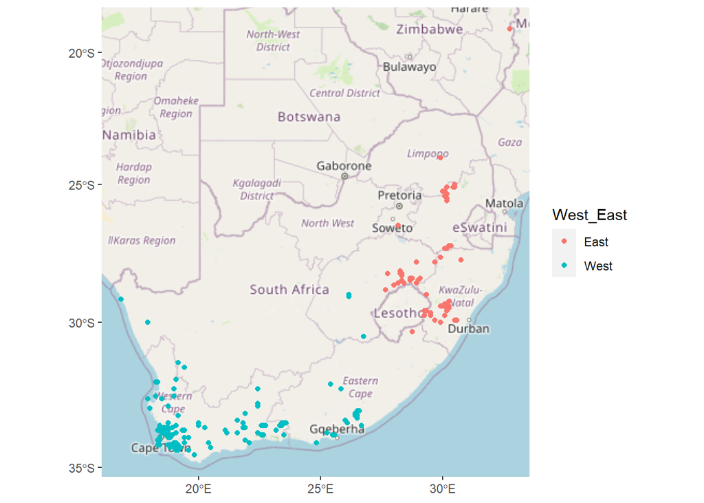

```r
ggplot() +
  annotation_map_tile(type = "osm", progress = "none", zoomin = -1) +
  geom_sf(data=Locations, aes(colour = West_East))
```